# Detroit Blight Prediction

I just completed a Machine Learning course on [Coursera](https://www.coursera.org/learn/python-machine-learning). The final assignment had a good exercise to combine several aspects of the course. The aim then though was just to pass the assignment and half the time was spent in trying to understand what the grader was looking for. Now that I have finished the course I have some time to dig deeper into the problem. This notebook hopefully helps me explore the various aspects I felt I should look into more while I was doing the assignment.

```python
import pandas as pd

df = pd.read_csv('ipython/train.csv')
```

```python
df = pd.read_csv('ipython/train.csv',low_memory=False)

print df.head()
```

```
   ticket_id                                     agency_name  \
0      22056  Buildings, Safety Engineering & Env Department
1      27586  Buildings, Safety Engineering & Env Department
2      22062  Buildings, Safety Engineering & Env Department
3      22084  Buildings, Safety Engineering & Env Department
4      22093  Buildings, Safety Engineering & Env Department

     inspector_name                      violator_name  \
0   Sims, Martinzie  INVESTMENT INC., MIDWEST MORTGAGE
1  Williams, Darrin           Michigan, Covenant House
2   Sims, Martinzie                    SANDERS, DERRON
3   Sims, Martinzie                       MOROSI, MIKE
4   Sims, Martinzie                    NATHANIEL, NEAL

   violation_street_number violation_street_name  violation_zip_code  \
```

[output cut: 35 more lines]

Let us set ticket_id as the index. Let us also try to get the count of missing data in each column Seaborn is a new package I'm exploring. The cool color tones have a more d3js feel to it

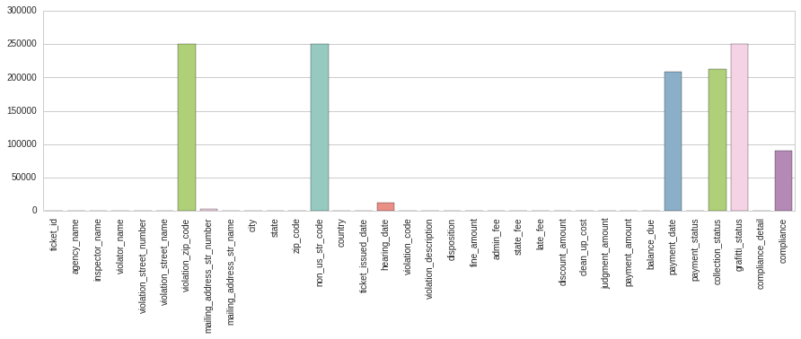

```python
#df.set_index(['ticket_id'],inplace=True)
import matplotlib.pyplot as plt
import seaborn as sns

x = df.columns
y = df.isnull().sum()

plt.figure(figsize=(15,4))
sns.set_style("whitegrid")
sns.barplot(x,y,palette="Set3")
plt.xticks(rotation=90)
plt.show()
```

Clearly some of the columns are almost empty. There is no information we can extract from them even if we come up with a filling strategy. Its better to drop these columns

```python
print 'Original DataFrame shape: ', df.shape
for k in df.columns:
    if df[k].isnull().sum() >= len(df[k])*0.5:
        df.drop([k],axis=1,inplace=True)

print 'DataFrame shape after dropping few columns: ',  df.shape
```

```
Original DataFrame shape:  (250306, 34)
DataFrame shape after dropping few columns:  (250306, 29)
```

```python
print df.isnull().sum()
```

```
ticket_id                         0
agency_name                       0
inspector_name                    0
violator_name                    34
violation_street_number           0
violation_street_name             0
mailing_address_str_number     3602
mailing_address_str_name          4
city                              0
state                            93
zip_code                          1
country                           0
ticket_issued_date                0
hearing_date                  12491
violation_code                    0
violation_description             0
disposition                       0
fine_amount                       1
admin_fee                         0
state_fee                         0
late_fee                          0
discount_amount                   0
clean_up_cost                     0
judgment_amount                   0
payment_amount                    0
balance_due                       0
payment_status                    0
compliance_detail                 0
compliance                    90426
dtype: int64
```

We still have a few columns that have missing data. 'compliance' is the target value. From the description of the data it seems like missing 'compliance' values refer to cases where the person is no longer required to pay the fine amount.There is one missing zip_code row that is also dropped. We can drop these rows. 'mailing_address_str_number' is being dropped for simplicity.

```python
df.drop(['mailing_address_str_number'],axis=1,inplace=True)
print df.shape
```

[output not shown]

With these we came down from 250306 rows to 159879.

The discussion forum for the course hinted at using the time between hearing date and the ticket issued date as a derived feature for better accuracy. I dont understand why that is a factor yet but hopefully we can plot a scatter matrix later and figure out what the trend is like for this feature.

For now let us extract that feature.

To do that we need to first convert the two time features to 'to_datetime' then we need to get the seconds difference between the two dates so that the feature becomes an int

For this let us define a function that converts the date, hour and minute difference between the two features into seconds

```python
def diff_seconds(date2, date1):
   res =  (date2.dt.date - date1.dt.date).dt.total_seconds()
   res += (date2.dt.hour - date1.dt.hour) * 3600
   res += (date2.dt.minute - date1.dt.minute) * 60
   res += date2.dt.second - date1.dt.second
   return res
```

```python
df['hearing_date'] = pd.to_datetime(df['hearing_date'].fillna('1900-01-01 00:00:00'))
df['ticket_issued_date'] = pd.to_datetime(df['ticket_issued_date'].fillna('1900-01-01 00:00:00'))

for col in ['ticket_issued_date', 'hearing_date']:
                df[col] = pd.to_datetime(df[col])

date1 = df.ticket_issued_date
date2 = df.hearing_date

print 'Start date ',df.ticket_issued_date.iloc[10]
print 'End date ',df.hearing_date.iloc[10]
print 'Number of seconds between them ',diff_seconds(date2, date1).iloc[10],'s'
df['sec_diff'] = diff_seconds(date2, date1)

df.zip_code = pd.to_numeric(df.zip_code, errors='coerce')
df.dropna(axis=0,subset=['compliance','zip_code'],how='any',inplace=True)
```

```
Start date  2004-10-07 12:00:00
End date  2005-02-22 15:00:00
Number of seconds between them  11934000.0 s
```

Let us now drop the columns that are not in test data to prevent data leak. Also lets drop all categorical data for now. We will come back and visit this again later. df.dtypes lists the data types of all columns. We are selection only 'float64' and 'int64' columns.

```python
import numpy as np
print df.dtypes

df_new = df.select_dtypes(include=['float64','int64']).copy()
print df_new.columns
```

```
ticket_id                            int64
agency_name                         object
inspector_name                      object
violator_name                       object
violation_street_number            float64
violation_street_name               object
mailing_address_str_name            object
city                                object
state                               object
zip_code                           float64
country                             object
ticket_issued_date          datetime64[ns]
hearing_date                datetime64[ns]
violation_code                      object
violation_description               object
disposition                         object
fine_amount                        float64
admin_fee                          float64
state_fee                          float64
late_fee                           float64
discount_amount                    float64
clean_up_cost                      float64
judgment_amount                    float64
payment_amount                     float64
balance_due                        float64
payment_status                      object
compliance_detail                   object
compliance                         float64
sec_diff                           float64
dtype: object
Index([u'ticket_id', u'violation_street_number', u'zip_code', u'fine_amount',
       u'admin_fee', u'state_fee', u'late_fee', u'discount_amount',
       u'clean_up_cost', u'judgment_amount', u'payment_amount', u'balance_due',
       u'compliance', u'sec_diff'],
      dtype='object')
```

```python
df_new.drop(['payment_amount','balance_due'],axis=1,inplace=True)
```

Our target variable is 'compliance' and 'ticket_id' is the index. Let us assign them.

```python
df_new.set_index(['ticket_id'],inplace=True)
y = df_new.compliance
#
print df_new.isnull().sum()
```

```
violation_street_number    0
zip_code                   0
fine_amount                0
admin_fee                  0
state_fee                  0
late_fee                   0
discount_amount            0
clean_up_cost              0
judgment_amount            0
compliance                 0
sec_diff                   0
dtype: int64
```

```python
df_new.drop(['compliance'],axis=1,inplace=True)
```

Among the remaining features let us see what the important features are using RandomForestClassifier

```python
from sklearn.ensemble import RandomForestClassifier
def feature_imp(X,y):
    # Build a forest and compute the feature importances
    forest = RandomForestClassifier(n_estimators=100,random_state=0)

    forest.fit(X, y)
    importances = forest.feature_importances_
    std = np.std([tree.feature_importances_ for tree in forest.estimators_],
                 axis=0)
    indices = np.argsort(importances)[::-1]

    # Print the feature ranking
    print("Feature ranking:")

    for f in range(X.shape[1]):
        print("%d. feature %d (%s) (%f) " % (f + 1, indices[f],X.columns[indices[f]], importances[indices[f]]))

    # Plot the feature importances of the forest
    plt.figure()
    plt.title("Feature importances")
    sns.set_style("whitegrid")
    sns.barplot(X.columns[indices],importances[indices],ci=std,palette="Set3")
    plt.xticks(rotation=90)
    plt.show()
    #print(importances,X.columns)
    return
```

```
Feature ranking:
1. feature 9 (sec_diff) (0.329555)
2. feature 0 (violation_street_number) (0.313261)
3. feature 1 (zip_code) (0.164768)
4. feature 5 (late_fee) (0.100887)
5. feature 6 (discount_amount) (0.052369)
6. feature 8 (judgment_amount) (0.023186)
7. feature 2 (fine_amount) (0.015975)
8. feature 7 (clean_up_cost) (0.000000)
9. feature 4 (state_fee) (0.000000)
10. feature 3 (admin_fee) (0.000000)
```

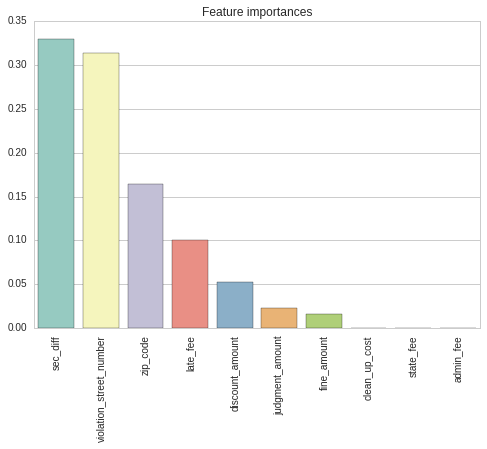

```python
feature_imp(df_new,y)
```

Let us now make a 70-30 split of the train data using the test_train_split function

```python
from sklearn.model_selection import train_test_split
X_train, X_test, y_train, y_test = train_test_split(df_new, y, train_size=0.7,random_state=0)
```

```python
from sklearn.linear_model import LogisticRegression
from sklearn.metrics import roc_auc_score

clf = LogisticRegression(C=10,penalty='l1')
clf.fit(X_train,y_train)

y_pred = clf.predict_proba(X_test)[:,-1]

print roc_auc_score(y_test,y_pred)
```

```
0.761098194101
```

So we fit a LogisticRegression model to the train data and predicted the probability of the output class using the pedict_proba function. Since we are using the L1 regularization with LogisticReression normalizing the input features will yield better results. Let us normalize the feature using MinMax Scaler and refit the LogisticRegression model to it.

```python
from sklearn.preprocessing import MinMaxScaler

df_scaled = pd.DataFrame(MinMaxScaler().fit_transform(df_new))
df_scaled.columns = df_new.columns


X_train, X_test, y_train, y_test = train_test_split(df_scaled, y, train_size=0.7,random_state=0)

clf.fit(X_train,y_train)

y_pred = clf.predict_proba(X_test)[:,-1]

print roc_auc_score(y_test,y_pred)
```

```
0.761101514614
```

We got a slight improvement by just scaling the input features. We can now tune the model parameters using the GridSearch Technique.

```python
from sklearn.model_selection import GridSearchCV
#
tuned_parameters = [{'penalty': ['l1','l2'],
                     'C': [0.01, 0.1, 1, 10, 100]}]
scores = ['precision']
for score in scores:
    m = GridSearchCV(clf, tuned_parameters,cv=3, scoring=score)
    m.fit(X_train,y_train)
#            #print(m)
print(m.best_score_,m.best_params_)
```

```
(1.0, {'penalty': 'l2', 'C': 0.1})
```

The GridSearch finds C=0.1 and L2 penalty as the optimal parameters that give the best precision. Using these parameters we get a slight improvement in the AUC

```python
clf = LogisticRegression(C=0.1,penalty='l2')
#clf = LogisticRegression()
clf.fit(X_train,y_train)

y_pred = clf.predict_proba(X_test)[:,-1]

print roc_auc_score(y_test,y_pred)
```

```
0.762379583289
```

I've referred to the explanation of ROC curve and AUC [from here](http://blog.yhat.com/posts/roc-curves.html)

"Receiving Operating Characteristic, or ROC, is a visual way for inspecting the performance of a binary classifier (0/1). In particular, it's comparing the rate at which your classifier is making correct predictions (True Positives or TP) and the rate at which your classifier is making false alarms (False Positives or FP). When talking about True Positive Rate (TPR) or False Positive Rate (FPR) we're referring to the definitions below:

\begin{equation*} TPR=TruePositives/(TruePositives+FalseNegatives)\\ FPR=FalsePositives/(FalsePositives+TrueNegatives)\\ \end{equation*}

You might have heard of True Positives and True Negatives referred to as Sensitivity and Specificity. No matter what you call it, the big point here is we're measuring the trade off between the rate at which you can correctly predict something, with the rate at which you make an embarrassing blunder and predict something that doesn't happen."

```python
from sklearn import metrics
fpr, tpr, thresholds = metrics.roc_curve(y_test, y_pred, pos_label=1)

plt.figure()
plt.title("Receiving Operating Characteristic")
sns.set_style("whitegrid")
plt.plot(fpr,tpr,label='LogisticRegression',color='#40E0D0')
plt.fill_between(fpr,tpr,color='#CAE1FF')
plt.plot([0,1],[0,1],'k--',label='No Power')
```

We have tried LogisticRegression so far. Let us try another powerful model the Gradient Boosting Decision Tree classifier. For now the parameters of the model is left to default

```python
from sklearn.ensemble import GradientBoostingClassifier

clf = GradientBoostingClassifier()
clf.fit(X_train,y_train)

y_pred = clf.predict_proba(X_test)[:,-1]

print roc_auc_score(y_test,y_pred)
```

```
0.77782968524
```

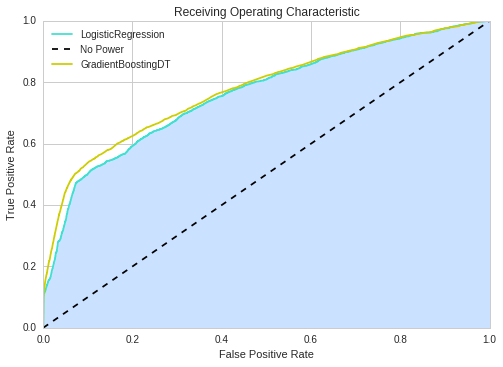

```python
fpr, tpr, thresholds = metrics.roc_curve(y_test, y_pred, pos_label=1)

plt.plot(fpr,tpr,label='GradientBoostingDT',color='#CDCD00')
plt.legend(loc=2)
plt.xlabel('False Positive Rate')
plt.ylabel('True Positive Rate')
plt.show()
```

```python
tuned_parameters = [{'n_estimators': [10,100,200],
                     'learning_rate': [0.01, 0.1, 1, 10]}]
scores = ['precision']
for score in scores:
    m = GridSearchCV(clf, tuned_parameters,cv=3, scoring=score)
    m.fit(X_train,y_train)
#            #print(m)
print(m.best_score_,m.best_params_)
```

```
(0.96480474066085109, {'n_estimators': 200, 'learning_rate': 0.01})
```

```python
clf = GradientBoostingClassifier(n_estimators=200,learning_rate=0.01)
clf.fit(X_train,y_train)

y_pred = clf.predict_proba(X_test)[:,-1]

print roc_auc_score(y_test,y_pred)
```

```
0.775240713497
```

The GridSearch exercise clearly didnt add much value this time.